# Exponential Distribution Simulations and the Central Limit Theorem Example

John Rusnak

August 20, 2016

## Synopsis

This project for the Statistical Inference Class examines the properties of the Central Limit Theorem. One thousand simulations of sample size 40 will be taken from an exponential distribution with lambda=0.2. Means will be calculated for each of the 1000 simulations and the resulting distribution of the sample means will be evaluated and compared to the theoretical values based on the Central Limit Theorem.

## Simulation and analysis of data

### Simulation of data from exponential distribution

First lets look at the Exponential Distribution that we will be using for the simulations. Figure:1 below is the histogram of 1000 samples from the given distribution with lambda= 0.2. We see from the histogram that the distribution does not look anything like a normal distribution.

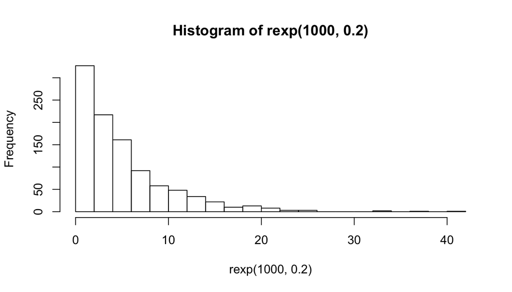

Figure:1 1000 simulations from Exp Dist lambda=0.2

```r
set.seed(1000)
hist(rexp(1000,.2),breaks=20)
```

### Run 1000 simulations of sample size=40 from the exponential distribution and calculate the mean for each

```r
set.seed(3)
n=40
d=1000
l=.2
set.seed(3)
mns = NULL
for (i in 1 : d) mns = c(mns, mean(rexp(n,l)))
```

### Graphical depiction of the distribution of sample means from above step of 1000 simulations

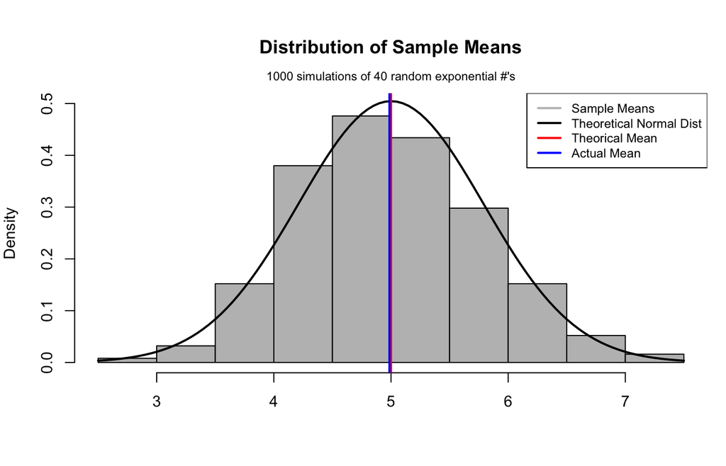

Figure:2 Histrogram of Distribution of Sample Means

```r
par(mar=c(5,4,5,1),cex=0.9)
hist(mns,freq=F, col = "grey",xlab="",ylim=c(0.0,0.5),
   main="Distribution of Sample Means")
mtext("1000 simulations of 40 random exponential #'s",side=3,cex=0.7,line=0.5)
curve(dnorm(x,mean=1/l,sd=1/l*1/sqrt(n)),add=TRUE,lwd=2,col="black")
abline(v=1/l,col="red",lwd=2)
abline(v=mean(mns),col="blue",lwd=2)
legend("topright",col=c("gray","black","red","blue"),legend=c("Sample Means",
     "Theoretical Normal Dist","Theorical Mean","Actual Mean"),lwd=2,cex=0.8)
```

- Created density histogram of the sample means shown above as Figure:2
- Added a curve of a normal distribution with mean=1/lambda and sd of 1/lambda *1/sqrt(40) the theoretical values of the normal distribution based on the central limit theory.
- Added vertical red line for the theoretical mean of distribution of sample means of 1/lambda or 5
- Added vertical blue line for the calculated actual mean of the distribution of sample means

### Analysis of theoretical versus actual values for mean and sd of the sample mean distribution

```r
actual<-c("mean"=round(mean(mns),4),"std"=round(sd(mns),4))
theoretical<-c("mean"=round(1/l,4),"std"=round(1/l*1/sqrt(n),4))
table<-rbind(theoretical,actual)
```

According to the central limit theorem, the theoretical mean of the distribution of sample means should approximate the mean of the underlying exponential distribution which is 1/lambda or 1/0.2 or 5. The theoretical standard deviation of the sample mean distribution should be 1/lambda * 1/sqrt(n) or .7906. The following table compares the theoretical values with the actual values.

```r
table
```

```
##               mean    std
## theoretical 5.0000 0.7906
## actual      4.9866 0.7948
```

As we can see from the table above, the simulation confirms the expected mean and sd of the distribution of sample means based on the central limit theorem.

### Does the distibution of sample means appear to be normal?

Visually based on Figure:2, comparing the normal distribution curve to the histogram, the answer appears to be yes. Lets also look at some basic summary statistics for the distribution of sample means:

```r
summary(mns)
```

```
##    Min. 1st Qu.  Median    Mean 3rd Qu.    Max.
##   2.567   4.406   4.945   4.987   5.522   7.457
```

As previously noted, the actual mean is 4.987 close to the theoretical mean of 5. The median at 4.945 is close to the mean implying symmetry about the mean. Lets look at the theoretical 25th and 75th quartiles for the nornal distribution compared to the actual results.

```r
x<-qnorm(.25,5,5/sqrt(40))
```

The theoretical 25th quartile is 4.466769 and the actual is 4.406 again close.

```r
y<-qnorm(.75,5,5/sqrt(40))
```

The theoretical 75th quartile is 5.533231 and the actual is 5.522 again close.

## Conclusions

This assignment showed the power of the Central Limit Theorem. The underlying exponential distribution was not close to be a normal distribution, but generating 1000 simulations of sample size 40 and then taking the mean of the sample for each of the 1000 simulations did produce, per the theorem, a distribution of sample means that basically was normal with a mean approximating the mean of the underlying exponential distribution(1/lambda) and a standard deviation approximating (1/lambda)/sqrt(n).